# Getting started with bigPLScox

Frédéric Bertrand

Cedric, Cnam, Paris  
frederic.bertrand@lecnam.net

2025-11-17

# Why bigPLScox?

**bigPLScox** implements Partial Least Squares (PLS) extensions of the Cox proportional hazards model that remain stable in high-dimensional survival settings. The package now ships with three complementary engines:

- `coxgpls()` – the classical matrix-based estimator with optional sparse and grouped variants (e.g. `coxsgpls()`, `coxspls_sgpls()`).
- `big_pls_cox_fast()` – the new Armadillo backend that produces variance-one components and supports both dense matrices and `bigmemory::big.matrix` objects through the same interface.
- `big_pls_cox_gd()` – a stochastic gradient descent solver that streams data from disk and converges quickly even when only a subset of predictors remains active at each step.

Together with the deviance-residual solvers and cross-validation helpers, these functions cover the most common modelling workflows. This vignette walks through those workflows using the bundled allelotyping dataset.

# Loading the example data

```r
library(bigPLScox)

data(micro.censure)
data(Xmicro.censure_compl_imp)

Y_all <- micro.censure$survyear[1:80]
status_all <- micro.censure$DC[1:80]
X_all <- apply(
  as.matrix(Xmicro.censure_compl_imp),
  MARGIN = 2,
  FUN = as.numeric
)[1:80, ]

set.seed(2024)
train_id <- 1:60
test_id <- 61:80

X_train <- X_all[train_id, ]
X_test <- X_all[test_id, ]
Y_train <- Y_all[train_id]
Y_test <- Y_all[test_id]
status_train <- status_all[train_id]
status_test <- status_all[test_id]
```

The original factor-based design matrix is also available if you wish to leverage the formula interface.

```r
X_train_raw <- Xmicro.censure_compl_imp[train_id, ]
X_test_raw <- Xmicro.censure_compl_imp[test_id, ]
```

# Inspecting deviance residuals

Deviance residuals can reveal problematic observations before any components are extracted. The helper `computeDR()` exposes both an R and a C++ engine; the latter is substantially faster and powers the new fast PLS routines.

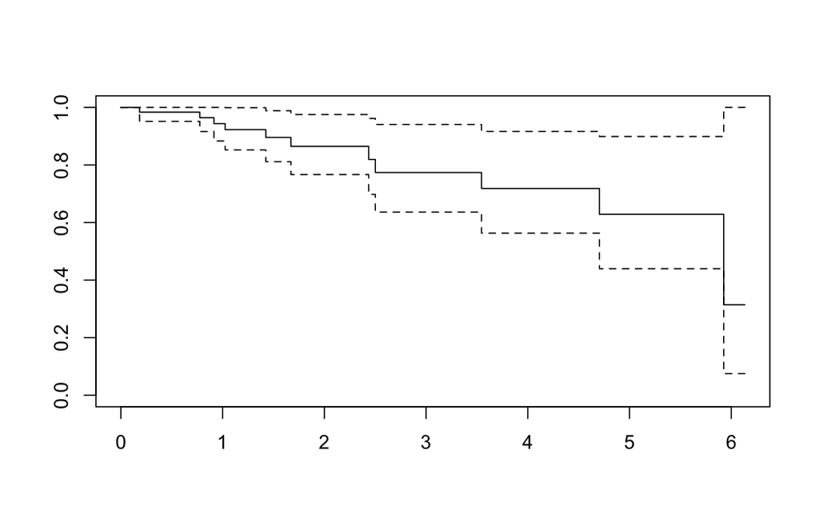

```r
residuals_overview <- computeDR(Y_train, status_train, plot = TRUE)
```

```r
eta_null <- rep(0, length(Y_train))
head(residuals_overview)
```

```
#>          1          2          3          4          5          6
#> -1.3771591 -0.5360370 -0.2693493 -0.3994329 -0.8040940 -0.3994329
```

```r
if (requireNamespace("bench", quietly = TRUE)) {
  benchmark_dr <- bench::mark(
    survival = computeDR(Y_train, status_train, engine = "survival"),
    cpp = computeDR(Y_train, status_train, engine = "cpp", eta = eta_null),
    iterations = 10,
    check = FALSE
  )
  benchmark_dr
}
```

```
#> # A tibble: 2 × 6
#>   expression      min   median `itr/sec` mem_alloc `gc/sec`
#>   <bch:expr> <bch:tm> <bch:tm>     <dbl> <bch:byt>    <dbl>
#> 1 survival      823µs    848µs     1154.   153.4KB        0
#> 2 cpp            88µs   91.1µs    10344.    24.1KB        0
```

```r
all.equal(
  as.numeric(computeDR(Y_train, status_train, engine = "survival")),
  as.numeric(computeDR(Y_train, status_train, engine = "cpp", eta = eta_null)),
  tolerance = 1e-7
)
```

```
#> [1] TRUE
```

# Matrix-based PLS–Cox models

The matrix interface mimics `survival::coxph()` while augmenting the predictor space with latent components. Most users start with `coxgpls()` and the cross-validation helper `cv.coxgpls()`.

```r
set.seed(123)
cox_pls_fit <- coxgpls(
  Xplan = X_train,
  time = Y_train,
  status = status_train,
  ncomp = 6,
  ind.block.x = c(3, 10, 20)
)
cox_pls_fit
```

```
#> Call:
#> coxph(formula = YCsurv ~ ., data = tt_gpls)
#>
#>          coef exp(coef) se(coef)      z        p
#> dim.1 -0.7368    0.4786   0.1162 -6.340  2.3e-10
#> dim.2 -0.5256    0.5912   0.1382 -3.804 0.000142
#> dim.3 -0.3314    0.7179   0.1199 -2.763 0.005720
#> dim.4 -0.2883    0.7495   0.1092 -2.641 0.008272
#> dim.5 -0.4002    0.6702   0.1435 -2.788 0.005298
#> dim.6 -0.2696    0.7636   0.1239 -2.176 0.029529
#>
#> Likelihood ratio test=60.94  on 6 df, p=2.906e-11
#> n= 60, number of events= 60
```

The formula interface accepts data frames containing the predictors along with survival outcomes.

```r
cox_pls_fit_formula <- coxgpls(
  ~ ., Y_train, status_train,
  ncomp = 6,
  ind.block.x = c(3, 10, 20),
  dataXplan = data.frame(X_train_raw)
)
cox_pls_fit_formula
```

```
#> Call:
#> coxph(formula = YCsurv ~ ., data = tt_gpls)
#>
#>           coef exp(coef) se(coef)      z       p
#> dim.1 -0.82612   0.43775  0.31903 -2.589 0.00961
#> dim.2 -0.79075   0.45350  0.39461 -2.004 0.04508
#> dim.3 -0.89888   0.40703  0.30294 -2.967 0.00301
#> dim.4  0.02354   1.02382  0.29663  0.079 0.93675
#> dim.5 -0.40714   0.66555  0.40456 -1.006 0.31423
#> dim.6 -0.53689   0.58456  0.38554 -1.393 0.16374
#>
#> Likelihood ratio test=19.59  on 6 df, p=0.00328
#> n= 60, number of events= 11
```

## Cross-validation

Repeated cross-validation stabilises the choice of latent components. The returned object records the optimal number of components and diagnostic curves.

```r
set.seed(123456)
cv_results <- suppressWarnings(cv.coxgpls(
  list(x = X_train, time = Y_train, status = status_train),
  nt = 6,
  ind.block.x = c(3, 10, 20)
))
```

```
#> CV Fold 1
#> CV Fold 2
#> CV Fold 3
#> CV Fold 4
#> CV Fold 5
```

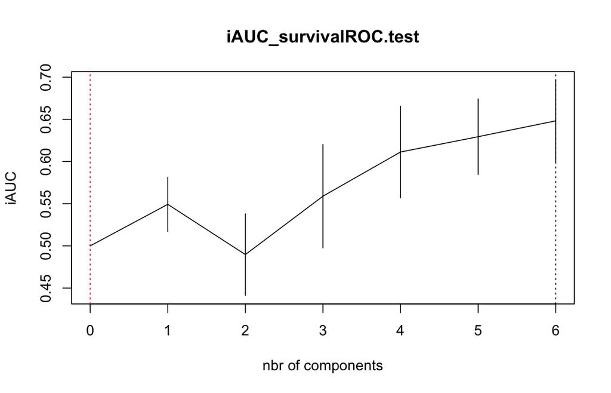

```r
cv_results
```

```
#> $nt
#> [1] 6
#>
#> $cv.error10
#> [1] 0.5000000 0.5492633 0.4897065 0.5589258 0.6112917 0.6294183 0.6482323
#>
#> $cv.se10
#> [1] 0.00000000 0.03211886 0.04830433 0.06137605 0.05429528 0.04481718 0.04814978
#>
#> $folds
#> $folds$`1`
#>  [1] 60 45  3 57 21 15 35 22 51 12 20 13
#>
#> $folds$`2`
#>  [1] 42 54 50 28  1 41  6 18 44  8 27 25
#>
#> $folds$`3`
#>  [1] 59 36 55 52 24 46 37 19  4 47 33  5
#>
#> $folds$`4`
#>  [1] 49 38 30  2 34 48 53 31 11 56 26 39
#>
#> $folds$`5`
#>  [1]  7 10 23 16 14 58 29  9 43 17 40 32
#>
#>
#> $lambda.min10
#> [1] 6
#>
#> $lambda.1se10
#> [1] 0
```

Use the selected number of components to refit with the deviance-residual solver for a robustness check.

```r
set.seed(123456)
cox_pls_dr <- coxgplsDR(
  Xplan = X_train,
  time = Y_train,
  status = status_train,
  ncomp = cv_results$nt,
  ind.block.x = c(3, 10, 20)
)
cox_pls_dr
```

```
#> Call:
#> coxph(formula = YCsurv ~ ., data = tt_gplsDR)
#>
#>         coef exp(coef) se(coef)     z        p
#> dim.1 0.7329    2.0812   0.1120 6.545 5.95e-11
#> dim.2 0.6418    1.8999   0.1456 4.409 1.04e-05
#> dim.3 0.3467    1.4144   0.1080 3.210  0.00133
#> dim.4 0.4266    1.5320   0.1554 2.745  0.00605
#> dim.5 0.3694    1.4468   0.1453 2.542  0.01101
#> dim.6 0.2884    1.3343   0.1095 2.633  0.00847
#>
#> Likelihood ratio test=63.84  on 6 df, p=7.442e-12
#> n= 60, number of events= 60
```

Sparse and structured sparse variants (`coxsgpls()`, `coxspls_sgpls()`) share the same workflow with additional arguments that control the number of selected predictors per component (`keepX`) or penalty strength.

# Fast solvers for medium-sized data

The new `big_pls_cox_fast()` routine exposes identical arguments for dense matrices and `big.matrix` objects. On moderate data it serves as a drop-in replacement for the original R implementation `big_pls_cox()`.

```r
fast_fit_dense <- big_pls_cox_fast(
  X = X_train,
  time = Y_train,
  status = status_train,
  ncomp = 4
)
summary(fast_fit_dense)
```

```
#> $n
#> [1] 60
#>
#> $p
#> [1] 40
#>
#> $ncomp
#> [1] 4
#>
#> $keepX
#> [1] 0 0 0 0
#>
#> $center
#>  [1]  0.4666667  0.4500000  0.4166667  0.5333333  0.5000000  0.5166667
#>  [7]  0.4833333  0.4000000  0.3833333  0.4500000  0.5166667  0.5166667
#> [13]  0.5500000  0.3666667  0.4333333  0.5333333  0.4833333  0.5166667
#> [19]  0.5500000  0.5166667  0.4333333  0.5666667  0.4000000  0.3833333
#> [25]  0.5166667  0.5166667  0.5666667  0.5333333  0.4666667  0.4500000
#> [31]  0.5500000  0.5500000  0.4500000  0.6333333 62.4622365  1.6833333
#> [37]  2.3833333  0.5166667  0.2500000  2.2666667
#>
#> $scale
#>  [1]  0.5030977  0.5016921  0.4971671  0.5030977  0.5042195  0.5039393
#>  [7]  0.5039393  0.4940322  0.4903014  0.5016921  0.5039393  0.5039393
#> [13]  0.5016921  0.4859611  0.4997174  0.5030977  0.5039393  0.5039393
#> [19]  0.5016921  0.5039393  0.4997174  0.4997174  0.4940322  0.4903014
#> [25]  0.5039393  0.5039393  0.4997174  0.5030977  0.5030977  0.5016921
#> [31]  0.5016921  0.5016921  0.5016921  0.4859611 14.6024282  0.7008873
#> [37]  0.9404591  0.7917299  0.4366669  1.2604367
#>
#> $cox
#> Call:
#> survival::coxph(formula = survival::Surv(time, status) ~ ., data = scores_df,
#>     ties = "efron", x = FALSE)
#>
#>   n= 60, number of events= 11
#>
#>          coef exp(coef) se(coef)      z Pr(>|z|)
#> comp1 -1.4836    0.2268   0.5002 -2.966  0.00301 **
#> comp2  1.3937    4.0299   0.5081  2.743  0.00609 **
#> comp3 -1.4271    0.2400   0.6997 -2.040  0.04138 *
#> comp4  0.9357    2.5490   0.5119  1.828  0.06755 .
#> ---
#> Signif. codes:  0 '***' 0.001 '**' 0.01 '*' 0.05 '.' 0.1 ' ' 1
#>
#>       exp(coef) exp(-coef) lower .95 upper .95
#> comp1    0.2268     4.4088    0.0851    0.6045
#> comp2    4.0299     0.2481    1.4887   10.9090
#> comp3    0.2400     4.1668    0.0609    0.9458
#> comp4    2.5490     0.3923    0.9347    6.9518
#>
#> Concordance= 0.962  (se = 0.015 )
#> Likelihood ratio test= 40.45  on 4 df,   p=3e-08
#> Wald test            = 15.58  on 4 df,   p=0.004
#> Score (logrank) test = 38.25  on 4 df,   p=1e-07
#>
#>
#> attr(,"class")
#> [1] "summary.big_pls_cox"
```

Predictions rely on the same `predict()` interface used by the classical function.

```r
linear_predictor_fast <- predict(fast_fit_dense, newdata = X_test, type = "link")
head(linear_predictor_fast)
```

```
#> [1]  3.3499156 -0.8685314  8.6594617 -6.5718861  2.0102711 -2.1990051
```

For comparison, the legacy solver is still available. The C++ backend usually reduces runtime by an order of magnitude while delivering components scaled to variance one.

```r
legacy_fit_dense <- big_pls_cox(
  X = X_train,
  time = Y_train,
  status = status_train,
  ncomp = 4
)
legacy_fit_dense$cox_fit
```

```
#> $coefficients
#> [1]  6.200427  3.171981 -2.748535  1.293296
#>
#> $var
#>           [,1]       [,2]       [,3]       [,4]
#> [1,]  5.821149  2.4185955 -2.3040552  1.0187707
#> [2,]  2.418596  1.6445800 -1.1764804  0.5610664
#> [3,] -2.304055 -1.1764804  1.2404846 -0.5308908
#> [4,]  1.018771  0.5610664 -0.5308908  0.3210964
#>
#> $loglik
#> [1] -33.823093  -6.374114
#>
#> $score
#> [1] 34.35164
#>
#> $iter
#> [1] 8
#>
#> $linear.predictors
#>  [1] -12.57620642  -0.80958795   3.92609801   2.60017390   1.76853806
#>  [6]  -3.36295838  -1.07944356  10.31904141  -3.64756309  -2.89617173
#> [11]  10.99977612  -3.67120048   0.19277160  -4.93349776   0.72346177
#> [16]  -2.96898338 -11.92153226 -16.36665206   7.29677779  -6.25230861
#> [21]  -7.44252580  -3.35748178   0.89833874  -0.03190649 -14.18767386
#> [26]  -5.70848324  10.05566087   2.33425751   1.44427382  -9.42823092
#> [31]  16.81484345  -8.16109725  -1.01887152   1.67809982   9.52923393
#> [36]  -0.81577205  13.21271969   4.03431692  -8.22578371   8.37431879
#> [41]   8.42795290   2.19412589  -1.95037872   2.94403579  -3.81221056
#> [46]  -0.29923400 -13.50366653   1.71522979   6.77552365  -1.04786702
#> [51]  -1.05373010   3.52071260   4.14906575  13.53253117  16.06054363
#> [56]  -9.18209817 -14.09511037   6.91845019   0.66507554   0.70227868
#>
#> $residuals
#>             1             2             3             4             5
#> -9.951099e-06 -1.028552e-05 -3.995987e-06 -2.023840e-05 -5.242897e-03
#>             6             7             8             9            10
#> -5.204999e-08 -5.106679e-07  2.996282e-01 -6.021565e-07 -1.784430e-09
#>            11            12            13            14            15
#>  9.535666e-01 -2.005207e-09 -1.822446e-06 -2.171991e-04 -6.660185e-08
```

[output cut: 12 more lines]

```
#>            46            47            48            49            50
#> -1.810061e-04 -4.119846e-08 -1.730902e-05 -1.316762e-03 -1.056724e-02
#>            51            52            53            54            55
#> -8.511766e-05 -1.970571e-02 -9.524699e-05 -1.325008e-01  6.950025e-01
#>            56            57            58            59            60
#> -2.377340e-09 -2.280448e-08 -3.265394e-05 -4.494326e-05 -1.805098e-03
#>
#> $means
#> [1]  3.330669e-17 -4.070818e-17 -4.996004e-17  3.700743e-18
#>
#> $method
#> [1] "efron"
#>
#> $class
#> [1] "coxph"
```

## Fast PLS Cox vs gradient based PLS Cox

The package provides two families of PLS Cox estimators:

- `big_pls_cox_fast`  
  Exact PLS components computed in compiled code, with a single Cox fit at the end.
- `big_pls_cox_gd`  
  A gradient based Cox optimisation performed in the latent PLS space.

Both approaches share the same preprocessing (centering and scaling), the same PLS deflation scheme and the same prediction interface. The main difference is how the final Cox coefficients are obtained.

In the exact fast path, we build PLS components that are tailored to Cox score residuals, then fit a Cox model once on the resulting scores. In the gradient based path, we optimise the partial log-likelihood directly in the space spanned by the PLS scores, using one of several optimisers.

The code below illustrates a typical benchmark on a moderate survival data set. The design is split into a training set used to fit the models and a test set used to evaluate concordance.

```r
set.seed(2024)
# Exact fast PLS Cox (dense)
fast_fit_dense <- big_pls_cox_fast(
  X     = X_train,
  time  = Y_train,
  status = status_train,
  ncomp = 4
)

# Exact fast PLS Cox (big.matrix)
if (requireNamespace("bigmemory", quietly = TRUE)) {
  library(bigmemory)
  X_big_train <- bigmemory::as.big.matrix(X_train)
  X_big_test  <- bigmemory::as.big.matrix(X_test)

  fast_fit_big <- big_pls_cox_fast(
    X      = X_big_train,
    time   = Y_train,
    status = status_train,
    ncomp  = 4
  )

  # Gradient based fit in the same latent space
  gd_fit <- big_pls_cox_gd(
    X        = X_big_train,
    time     = Y_train,
    status   = status_train,
    ncomp    = 4,
    max_iter = 2000
  )

  risk_table <- data.frame(
    subject   = seq_along(test_id),
    fast_dense = predict(fast_fit_dense, newdata = X_test, type = "link"),
    fast_big   = predict(fast_fit_big,   newdata = X_big_test, type = "link"),
    gd         = predict(gd_fit,         newdata = X_big_test, type = "link")
  )

  concordances <- apply(
    risk_table[-1],
    2,
    function(lp) {
      survival::concordance(
        survival::Surv(Y_test, status_test) ~ lp
      )$concordance
    }
  )

  concordances
}
```

```
#> fast_dense   fast_big         gd
#>  0.4418605  0.4418605  0.2790698
```

`big_pls_cox_gd()` is particularly useful for streamed data or when the number of active predictors per component is restricted via `keepX`.

# Predictions and evaluation

All solvers return latent scores and loadings that can be reused for plotting or external validation. Use `predict(..., type = "components")` to extract the scores directly.

```r
if (exists("fast_fit_dense")) {
  component_scores <- predict(fast_fit_dense, newdata = X_test, type = "components")
  head(component_scores)
}
```

```
#>             [,1]        [,2]       [,3]       [,4]
#> [1,] -0.61328247  1.45903382 -0.2024545  0.1256753
#> [2,] -0.14585655 -0.89077212 -0.3630109 -0.3863126
#> [3,] -2.49681489  1.07906464 -1.7437503  1.0288135
#> [4,] -0.01412341 -2.48245825  1.7023219 -0.7517977
#> [5,] -0.56984205 -0.10012954 -1.0183793 -0.1591913
#> [6,]  0.49642902 -0.09180402  0.5767821 -0.5465379
```

The concordance index provides a quick check of predictive ability on the test set.

```r
if (exists("fast_fit_dense")) {
  concordance_fast <- survival::concordance(
    survival::Surv(Y_test, status_test) ~ linear_predictor_fast
  )$concordance
  concordance_fast
}
```

```
#> [1] 0.4418605
```

# DK-splines extension

For flexible baseline hazards the `coxDKgplsDR()` estimator augments the PLS components with DK-splines. The interface mirrors the previous functions.

```r
cox_DKsplsDR_fit <- coxDKgplsDR(
  Xplan = X_train,
  time = Y_train,
  status = status_train,
  ncomp = 6,
  validation = "CV",
  ind.block.x = c(3, 10, 20),
  verbose = FALSE
)
cox_DKsplsDR_fit
```

```
#> Call:
#> coxph(formula = YCsurv ~ ., data = tt_DKgplsDR)
#>
#>          coef exp(coef) se(coef)     z        p
#> dim.1  4.4294   83.8841   0.7310 6.060 1.36e-09
#> dim.2  3.6711   39.2955   0.8183 4.487 7.24e-06
#> dim.3  3.8127   45.2712   1.0314 3.697 0.000218
#> dim.4  2.6709   14.4534   0.8963 2.980 0.002883
#> dim.5  1.6486    5.1998   0.6897 2.390 0.016827
#> dim.6  1.4384    4.2139   0.7022 2.048 0.040517
#>
#> Likelihood ratio test=66.07  on 6 df, p=2.612e-12
#> n= 60, number of events= 60
```

Cross-validation is available for the DK-splines estimator as well.

```r
set.seed(2468)
cv_coxDKgplsDR_res <- suppressWarnings(cv.coxDKgplsDR(
  list(x = X_train, time = Y_train, status = status_train),
  nt = 6,
  ind.block.x = c(3, 10, 20)
))
```

```
#> Kernel :  rbfdot
#> Estimated_sigma  0.01258323
#> CV Fold 1
#> Kernel :  rbfdot
#> Estimated_sigma  0.01471071
#> CV Fold 2
#> Kernel :  rbfdot
#> Estimated_sigma  0.0127949
#> CV Fold 3
#> Kernel :  rbfdot
#> Estimated_sigma  0.0122611
#> CV Fold 4
#> Kernel :  rbfdot
#> Estimated_sigma  0.01289496
#> CV Fold 5
```

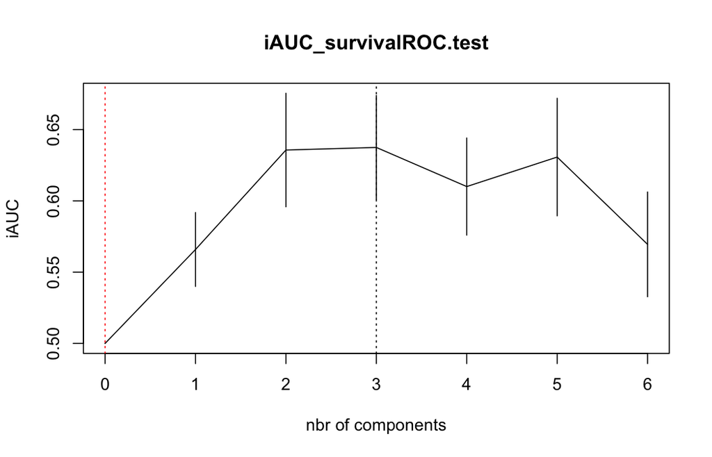

```r
cv_coxDKgplsDR_res
```

```
#> $nt
#> [1] 6
#>
#> $cv.error10
#> [1] 0.5000000 0.5658906 0.6356608 0.6374963 0.6100371 0.6307320 0.5694802
#>
#> $cv.se10
#> [1] 0.00000000 0.02591444 0.03982352 0.03646931 0.03407857 0.04124367 0.03676530
#>
#> $folds
#> $folds$`1`
#>  [1] 44 16 27 26 55 20 49 14  6 47 18  7
#>
#> $folds$`2`
#>  [1] 58  8  2 17  3 15 52 43 56 11 29 59
#>
#> $folds$`3`
#>  [1] 51 13 57 46 45 32 19  5 36 33 10 28
#>
#> $folds$`4`
#>  [1] 21 50 38 60 53 42 23 31 12 24  1 25
#>
#> $folds$`5`
#>  [1] 22 39 35 54  4 30 34 48 37 40  9 41
#>
#>
#> $lambda.min10
#> [1] 3
#>
#> $lambda.1se10
#> [1] 0
```

# Next steps

- `vignette("bigPLScox", package = "bigPLScox")` dives deeper into the fast big-memory backends and shows how to reconcile the dense and streaming implementations.
- `vignette("bigPLScox-benchmarking", package = "bigPLScox")` demonstrates a reproducible benchmarking workflow that contrasts the classical, fast, and gradient-descent solvers against `survival::coxph()`.
- The reference documentation (`help("big_pls_cox_fast")`, etc.) details every argument and return value for the modelling functions discussed above.